# Regression Modeling for Rental Property Price Prediction

Mithirendra Maniam

2023-11-15

## 1. Introduction

Renting a property is expensive in KL and Selangor. The purpose of this project is to build a linear regression model to predict the price of a property based on its size and number of bedrooms.

## 2. Data Collection

Data was obtained from Kaggle. The URL for the dataset is given here: [Property Rental Data] (https://www.kaggle.com/datasets/ariewijaya/rent-pricing-kuala-lumpur-malaysi/download?datasetVersionNumber=5)

This dataset contains information on rent pricing surrounding Kuala Lumpur and Selangor region, Malaysia. The information was scraped from mudah.my.

There are 13 features with one unique ids (ads_id) and one target feature (monthly_rent)

- `ads_id`: the listing ids (unique)
- `prop_name`: name of the building/ property
- `completion_year`: completion/ established year of the property
- `monthly_rent`: monthly rent in ringgit malaysia (RM)
- `location`: property location in Kuala Lumpur region
- `property_type`:property type such as apartment, condominium, flat, duplex, studio, etc
- `rooms`: number of rooms in the unit
- `parking`: number of parking space for the unit
- `bathroom`: number of bathrooms in the unit
- `size`: total area of the unit in square feet
- `furnished`: furnishing status of the unit (fully, partial, non-furnished)
- `facilities`: main facilities available
- `additional_facilities`: additional facilities (proximity to attraction area, mall, school, shopping, railways, etc)

Reading of data into R

```r
library(dplyr)
# Reading data from csv file
prop_data <- read.csv("mudah-apartment-kl-selangor.csv")
```

## 3. Data Cleaning

Check the dimensions of the data set.

```r
# Check the number of observations and columns in dataset
dim(prop_data)
```

```
## [1] 19991    14
```

Next we check the structure of the dataset.

```r
# Looking at structure of dataset
str(prop_data)
```

```
## 'data.frame':    19991 obs. of  14 variables:
##  $ ads_id               : int  100323185 100203973 100323128 100191767 97022692 100322897 100322962 100322885 100322866 100322863 ...
##  $ prop_name            : chr  "The Hipster @ Taman Desa" "Segar Courts" "Pangsapuri Teratak Muhibbah 2" "Sentul Point Suite Apartment" ...
##  $ completion_year      : num  2022 NA NA 2020 NA ...
##  $ monthly_rent         : chr  "RM 4 200 per month" "RM 2 300 per month" "RM 1 000 per month" "RM 1 700 per month" ...
##  $ location             : chr  "Kuala Lumpur - Taman Desa" "Kuala Lumpur - Cheras" "Kuala Lumpur - Taman Desa" "Kuala Lumpur - Sentul" ...
##  $ property_type        : chr  "Condominium" "Condominium" "Apartment" "Apartment" ...
##  $ rooms                : chr  "5" "3" "3" "2" ...
##  $ parking              : num  2 1 NA 1 1 1 2 1 1 1 ...
##  $ bathroom             : num  6 2 2 2 1 2 2 1 1 2 ...
##  $ size                 : chr  "1842 sq.ft." "1170 sq.ft." "650 sq.ft." "743 sq.ft." ...
##  $ furnished            : chr  "Fully Furnished" "Partially Furnished" "Fully Furnished" "Partially Furnished" ...
##  $ facilities           : chr  "Minimart, Gymnasium, Security, Playground, Swimming Pool, Parking, Lift, Barbeque area, Multipurpose hall, Jogging Track" "Playground, Parking, Barbeque area, Security, Jogging Track, Swimming Pool, Gymnasium, Lift, Sauna" "Minimart, Jogging Track, Lift, Swimming P…
##  $ additional_facilities: chr  "Air-Cond, Cooking Allowed, Washing Machine" "Air-Cond, Cooking Allowed, Near KTM/LRT" "" "Cooking Allowed, Near KTM/LRT, Washing Machine" ...
##  $ region               : chr  "Kuala Lumpur" "Kuala Lumpur" "Kuala Lumpur" "Kuala Lumpur" ...
```

We are looking for 3 variables to perform the prediction, namely `monthly_rent`, `size` and `rooms`. From the structure of the dataset above, it can be seen that all 3 variables are character classes. We should subset the columns in a new variable and convert this character variables into numeric variables so that we can run a regression model.

Also added the `property type` column to be able to choose the type of property, to allow for more accurate prediction.

```r
# Subset a few columns to create a new subset dataset
subprop_data <- prop_data[ , c(4,6,7,10)]
str(subprop_data)
```

```
## 'data.frame':    19991 obs. of  4 variables:
##  $ monthly_rent : chr  "RM 4 200 per month" "RM 2 300 per month" "RM 1 000 per month" "RM 1 700 per month" ...
##  $ property_type: chr  "Condominium" "Condominium" "Apartment" "Apartment" ...
##  $ rooms        : chr  "5" "3" "3" "2" ...
##  $ size         : chr  "1842 sq.ft." "1170 sq.ft." "650 sq.ft." "743 sq.ft." ...
```

### 3.1 Property Size Data

Below are the steps to prepare the Size column.

```r
# Change column from character to numeric
library(stringr)
subprop_data$size <- str_replace(subprop_data$size, " sq.ft.", "")
subprop_data$size <- as.numeric(subprop_data$size)
str(subprop_data)
```

[output not shown]

### 3.2 Property Room Number

Below are the steps to prepare the Room column.

```r
# Change column from character to numeric
subprop_data$rooms <- as.numeric(subprop_data$rooms)
str(subprop_data)
```

[output not shown]

### 3.3 Property Monthly Rent

Below are the steps to prepare the monthly_rent column.

```r
# Change column from character to numeric
subprop_data$monthly_rent <- str_replace(subprop_data$monthly_rent, " per month", "")
subprop_data$monthly_rent <- str_replace(subprop_data$monthly_rent, "RM ", "")
subprop_data$monthly_rent <- str_replace(subprop_data$monthly_rent, " ", "")
```

Convert monthly_rent column to numeric values.

```r
# Convert monthly-rent column to numeric type
subprop_data$monthly_rent <- as.numeric(subprop_data$monthly_rent)
str(subprop_data)
```

```
## 'data.frame':    19991 obs. of  4 variables:
##  $ monthly_rent : num  4200 2300 1000 1700 1299 ...
##  $ property_type: chr  "Condominium" "Condominium" "Apartment" "Apartment" ...
##  $ rooms        : num  5 3 3 2 1 3 3 1 2 3 ...
##  $ size         : num  1842 1170 650 743 494 ...
```

### 3.4 Property Type

Converting the Property Type column into factors and finding unique levels within column.

```r
# Remove data with weird property_type description
subprop_data[subprop_data$property_type == "Condo / Services residence / Penthouse / Townhouse", ]
```

```
##      monthly_rent                                      property_type rooms size
## 3669          150 Condo / Services residence / Penthouse / Townhouse    NA  100
```

```r
subprop_data <- subprop_data[-3669, ]

# Change column from character to numeric
subprop_data$property_type <- factor(subprop_data$property_type)
levels(subprop_data$property_type)
```

```
##  [1] "Apartment"         "Bungalow House"    "Condominium"
##  [4] "Duplex"            "Flat"              "Houses"
##  [7] "Others"            "Residential"       "Service Residence"
## [10] "Soho"              "Studio"            "Townhouse Condo"
```

## 4. Exploratory Data Analysis

```r
# Remove NAs
subprop_data <- na.omit(subprop_data)

# Drop unused levels after removing NAs
subprop_data <- droplevels(subprop_data)

# Summary statistics
summary(subprop_data$size)
```

```
##     Min.  1st Qu.   Median     Mean  3rd Qu.     Max.
##        1      750      886     5925     1044 99999999
```

```r
summary(subprop_data$rooms)
```

```
##    Min. 1st Qu.  Median    Mean 3rd Qu.    Max.
##    1.00    2.00    3.00    2.68    3.00   10.00
```

```r
summary(subprop_data$monthly_rent)
```

```
##    Min. 1st Qu.  Median    Mean 3rd Qu.    Max.
##      70    1100    1400    2150    1800  780000
```

```r
# Checking for outliers
tail(sort(subprop_data$size),20)
```

```
##  [1]     4000     4012     4098     4300     4300     4356     4915     4915
##  [9]     5000     5000     5000     6067     6400     7506     7800     8300
## [17]     9001    15000    48010 99999999
```

```r
tail(sort(subprop_data$rooms),20)
```

```
##  [1]  6  6  6  6  6  6  6  6  6  7  7  7  7  7  7  7  7  9  9 10
```

```r
tail(sort(subprop_data$monthly_rent),50)
```

```
##  [1]  13000  13500  13500  15000  15000  15000  15000  16000  16000  16000
## [11]  16000  16000  16800  16800  17000  18500  45000  95000 105000 125000
## [21] 127898 190000 200000 215000 230000 240000 249900 250000 250000 250000
## [31] 250000 260000 288000 290000 310000 320000 329999 330000 345000 345000
## [41] 349898 418000 419000 450000 480000 550000 580000 580000 580000 780000
```

```r
# Checking and deleting size column outliers
subprop_data[subprop_data$size > 40000,]
```

```
##      monthly_rent property_type rooms     size
## 1715          110   Condominium     1 99999999
## 2623         1400     Apartment     3    48010
```

```r
subprop_data <- subprop_data[-c(1715,2623),]

# Summary statistics
summary(subprop_data$size)
```

```
##    Min. 1st Qu.  Median    Mean 3rd Qu.    Max.
##     1.0   750.0   886.0   917.7  1043.0 15000.0
```

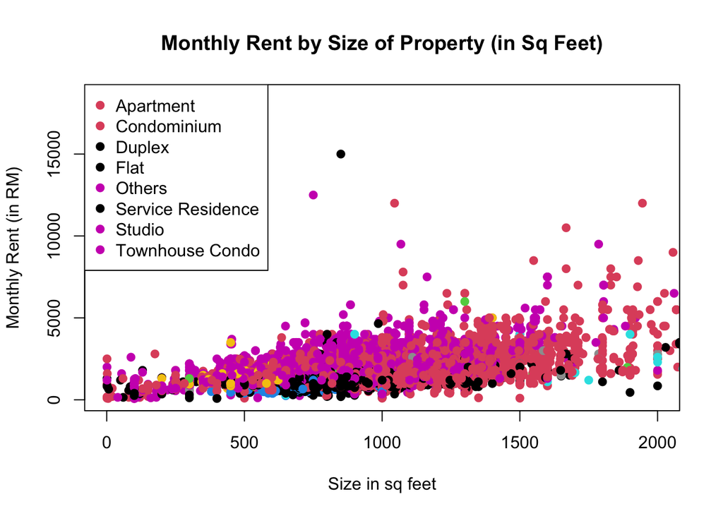

```r
# Checking and deleting monthly_rent column > 50000
subprop_data <- subprop_data[subprop_data$monthly_rent < 20000,]

# Check the distribution of monthly rent
plot(subprop_data$size, subprop_data$monthly_rent,
     xlim = c(0,2000),
     xlab = "Size in sq feet",
     ylab = "Monthly Rent (in RM)",
     pch = 19,
     col = subprop_data$property_type,
     main = "Monthly Rent by Size of Property (in Sq Feet)")
legend("topleft",
       legend = levels(subprop_data$property_type),
       pch = 19,
       col = subprop_data$property_type)
```

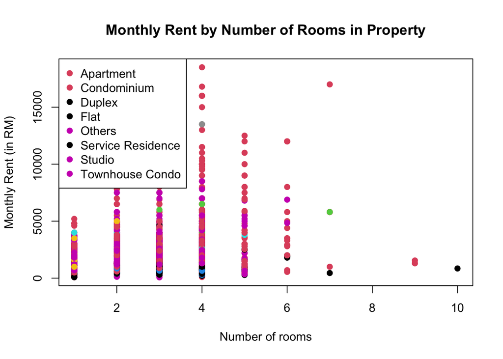

```r
plot(subprop_data$room, subprop_data$monthly_rent,
     xlab = "Number of rooms",
     ylab = "Monthly Rent (in RM)",
     pch = 19,
     col = subprop_data$property_type,
     main = "Monthly Rent by Number of Rooms in Property")
legend("topleft",
       legend = levels(subprop_data$property_type),
       pch = 19,
       col = subprop_data$property_type)
```

```r
# Check mean for each property type
tapply(subprop_data$monthly_rent, subprop_data$property_type, mean)
```

```
##         Apartment       Condominium            Duplex              Flat
##         1135.5581         1809.0172         1912.1711          812.1716
##            Others Service Residence            Studio   Townhouse Condo
##         1430.2299         1858.2250         1252.5556         2414.2571
```

## 5. Data Modeling and Prediction

Building a linear regression model using size and rooms to predict monthly rent.

```r
# Build a linear regression model
model <- lm(monthly_rent ~ rooms + size, data=subprop_data)
summary(model)
```

```
##
## Call:
## lm(formula = monthly_rent ~ rooms + size, data = subprop_data)
##
## Residuals:
##      Min       1Q   Median       3Q      Max
## -22836.3   -412.4   -125.0    232.0  15067.6
##
## Coefficients:
##               Estimate Std. Error t value Pr(>|t|)
## (Intercept)  675.99625   19.83607   34.08   <2e-16 ***
## rooms       -249.60645    8.29307  -30.10   <2e-16 ***
## size           1.74727    0.01899   92.00   <2e-16 ***
## ---
## Signif. codes:  0 '***' 0.001 '**' 0.01 '*' 0.05 '.' 0.1 ' ' 1
##
## Residual standard error: 782.8 on 19941 degrees of freedom
## Multiple R-squared:  0.3144, Adjusted R-squared:  0.3143
## F-statistic:  4572 on 2 and 19941 DF,  p-value: < 2.2e-16
```

## 6. Outcome - Predicting Price based on input of size and rooms

```r
# Function for predicting property rental
rental_predictor <- function(type, size, rooms) {
  subprop_type <- subprop_data[subprop_data$property_type == type,  ]
  model <- lm(monthly_rent ~ rooms + size, data=subprop_type)
  newdata <- data.frame(size, rooms)
  prediction <- predict(model, newdata)
  print(paste("The predicted rental price for a", type, "property with", rooms, "rooms and a size of", size,"sq feet is: ~RM", round(prediction,0)))
}
```

```r
rental_predictor("Apartment",1200, 3)
```

```
## [1] "The predicted rental price for a Apartment property with 3 rooms and a size of 1200 sq feet is: ~RM 1406"
```

```r
rental_predictor("Condominium",1000,3)
```

```
## [1] "The predicted rental price for a Condominium property with 3 rooms and a size of 1000 sq feet is: ~RM 1715"
```

```r
rental_predictor("Studio",400,1)
```

```
## [1] "The predicted rental price for a Studio property with 1 rooms and a size of 400 sq feet is: ~RM 1053"
```

[output not shown]